# Built-in

## `calepin`

`calepin` is the default documentation theme. It is designed for project documentation, manuals, notebook collections, and sites where navigation and reference lookup matter.

It includes sidebar navigation, a top bar, previous and next page links, an on-page table of contents, dark mode, copy buttons on code blocks, and rendered, source, and PDF view switching.

[figure not shown]

[figure not shown]

## `academic`

`academic` is a reading-first essay and blog theme. It is designed for articles, research notes, project blogs, and smaller websites that prioritize long-form reading over dense navigation.

It includes a centered narrow text column, margin-note support, top navigation, dark mode, copy buttons on code blocks, and the shared Calepin search and language controls.

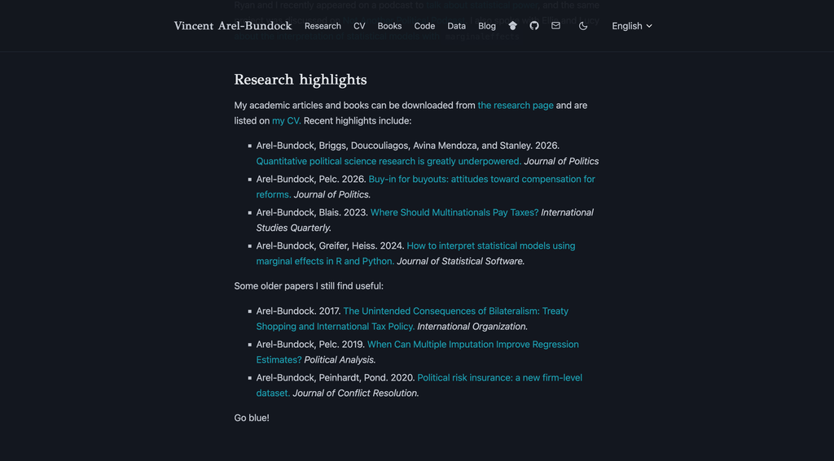

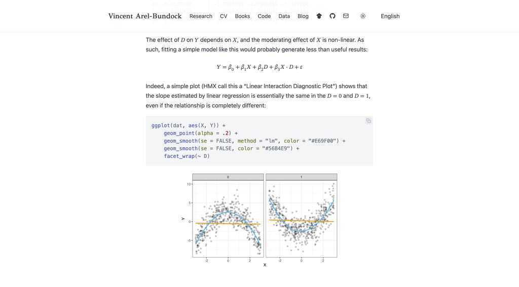

## `typst`

`typst` disables the website and notebook themed wrappers and uses raw Typst output. Use this when you want unstyled HTML or the output unchanged from the Typst source.